# Homework 6

FIRSTNAME LASTNAME

April 07, 2021

# Instructions

**Exercises:** 4 (20.4.6 Exercises); 1 (21.2.1 Exercises); 1 (21.5.3 Exercises); 1, 2 (23.2.1 Exercises)

**Submission:** Submit an electronic document on Gradescope. Must be submitted as a PDF file generated in RStudio. All assigned problems are chosen according to the textbook *R for Data Science*. You do not need R code to answer every question. If you answer without using R code, delete the code chunk. If the question requires R code, make sure you display R code. If the question requires a figure, make sure you display a figure. A lot of the questions can be answered in written response, but require R code and/or figures for understanding and explaining.

# Chapter 20 (20.4.6 Exercises)

## Exercise 4

### 1) The last value. Should you use `[` or `[[`?

Use `[[]]` notation because when the input is a list (a flexible type of vector), we want to return the last item of the list, rather than a list that only contains the last item.

```r
LastValue = function(vector){
    last_position = length(vector)
    vector[[last_position]]
}
```

### 2) The elements at even numbered positions.

```r
ValuesAtEvenIndices = function(vector){
    even_indices = 1:length(vector) %% 2 == 0
    vector[even_indices]
}
```

### 3) Every element except the last value.

```r
EverythingButLastValue = function(vector){
    last_position = length(vector)
    vector[[-last_position]]
}
```

### 4) Only even numbers (and no missing values).

```r
EvenValuesNonNA = function(vector){
    vector[vector %% 2 == 0 & !is.na(vector)]
}
```

# Chapter 21 (21.2.1 Exercises)

## Exercise 1

### 1) Compute the mean of every column in `mtcars`.

```r
for (i in seq_along(mtcars)){
    print(mean(mtcars[[i]]))
}
```

```
## [1] 20.09062
## [1] 6.1875
## [1] 230.7219
## [1] 146.6875
## [1] 3.596563
## [1] 3.21725
## [1] 17.84875
## [1] 0.4375
## [1] 0.40625
## [1] 3.6875
## [1] 2.8125
```

### 2) Determine the type of each column in `nycflights13::flights`.

```r
library(nycflights13)

for (i in seq_along(flights)){
    print(typeof(flights[[i]]))
}
```

```
## [1] "integer"
## [1] "integer"
## [1] "integer"
## [1] "integer"
## [1] "integer"
## [1] "double"
## [1] "integer"
## [1] "integer"
## [1] "double"
## [1] "character"
## [1] "integer"
## [1] "character"
## [1] "character"
## [1] "character"
## [1] "double"
## [1] "double"
## [1] "double"
## [1] "double"
## [1] "double"
```

### 3) Compute the number of unique values in each column of `iris`.

```r
for (i in seq_along(iris)){
    unique_values_in_column = unique(iris[[i]])
    number_of_unique_values = length(unique_values_in_column)
    print(number_of_unique_values)
}
```

```
## [1] 35
## [1] 23
## [1] 43
## [1] 22
## [1] 3
```

### 4) Generate 10 random normals from distributions with means of -10, 0, 10, and 100.

```r
map(c(-10, 0, 10, 100), rnorm, n=10, sd=1) # It's ok to not specify sd=1.
```

```
## [[1]]
##  [1] -10.523994  -8.397456  -9.360334  -9.618157  -9.676876  -8.478720
##  [7] -10.172060 -10.514928  -9.688697  -9.858282
##
## [[2]]
##  [1] -0.9727623 -2.4363378  0.7379936  0.4064408  0.8198021 -0.5134373
##  [7] -0.0207081 -1.1991002  2.8685089 -1.8640674
##
## [[3]]
##  [1]  9.324803  9.834070  9.059493  9.628804 10.070414 11.063334 10.771006
##  [8]  9.696020  8.695431 10.294569
##
## [[4]]
##  [1]  99.92154 101.13947  99.29920 101.60048  99.86440 100.13518 100.18271
##  [8] 100.84864  99.07350 100.10269
```

# Chapter 21 (21.5.3 Exercises)

## Exercise 1

Write code that uses one of the map functions to:

### 1) Compute the mean of every column in `mtcars`.

```r
map_dbl(mtcars, mean) # Alternative solution: map(mtcars, mean)
```

```
##        mpg        cyl       disp         hp       drat         wt       qsec
##  20.090625   6.187500 230.721875 146.687500   3.596563   3.217250  17.848750
##         vs         am       gear       carb
##   0.437500   0.406250   3.687500   2.812500
```

### 2) Determine the type of each column in `nycflights13::flights`.

```r
map_chr(flights, typeof) # Alternative solution: map(mtcars, mean)
```

```
##           year          month            day       dep_time sched_dep_time
##      "integer"      "integer"      "integer"      "integer"      "integer"
##      dep_delay       arr_time sched_arr_time      arr_delay        carrier
##       "double"      "integer"      "integer"       "double"    "character"
##         flight        tailnum         origin           dest       air_time
##      "integer"    "character"    "character"    "character"       "double"
##       distance           hour         minute      time_hour
##       "double"       "double"       "double"       "double"
```

### 3) Compute the number of unique values in each column of `iris`.

```r
iris %>% map(unique) %>% map_int(length) # Alternative solution: iris %>% map(unique) %>% map(length)
```

```
## Sepal.Length  Sepal.Width Petal.Length  Petal.Width      Species
##           35           23           43           22            3
```

### 4) Generate 10 random normals from distributions with means of -10, 0, 10, and 100.

```r
map(c(-10, 0, 10, 100), rnorm, n=10)
```

```
## [[1]]
##  [1] -11.593481  -9.391796 -11.812322 -11.737797  -9.421384 -11.315413
##  [7] -10.314316  -8.280489 -10.232445 -10.015649
##
## [[2]]
##  [1] -1.52296303 -1.16254751  2.18080607  0.90901545  0.13224356 -0.09599310
##  [7] -0.49840017 -1.19833122 -0.07706799  0.33574390
##
## [[3]]
##  [1] 11.690110 12.853741 10.487085  9.791318 10.269341  9.494724 10.744880
##  [8]  9.608432  9.063344  9.942682
##
## [[4]]
##  [1]  99.92831  97.15858 100.34236  99.93514 101.74155  98.72342 100.29731
##  [8]  99.53254  98.58565 100.45713
```

# Chapter 23 (23.2.1 Exercises)

## Exercise 1

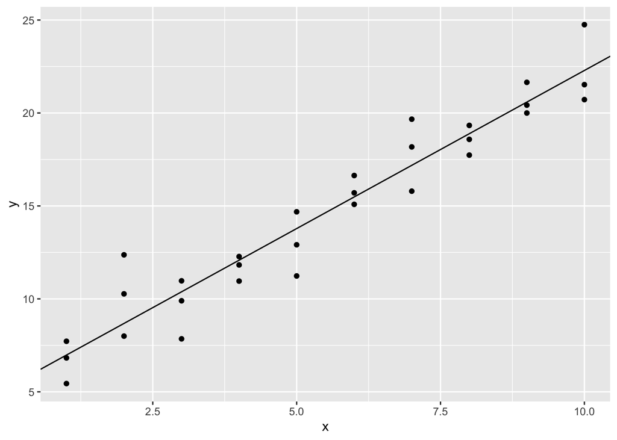

```r
sim1a <- tibble(
  x = rep(1:10, each = 3),
  y = x * 1.5 + 6 + rt(length(x), df = 2)
)

model = lm(y ~ x, data=sim1a)
coefs = coef(model)
ggplot(sim1a, aes(x, y)) + geom_point() + geom_abline(intercept=coefs[1], slope=coefs[2])
```

If we run this a bunch of times (at least 10), we’ll see some large outliers randomly come up that cause the model fit to be quite a bit different (for example it might be almost flat, the intercept could be very high or low, etc). The linear model is especially sensitive to these outliers because of the squared term in the distance function.

## Exercise 2

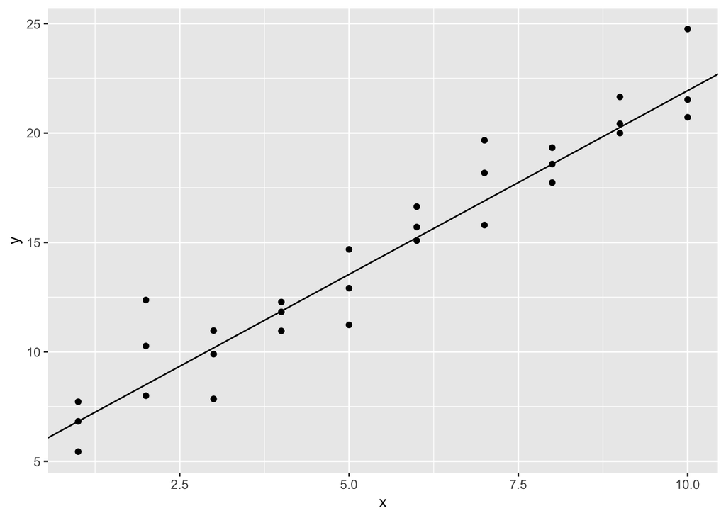

```r
make_prediction = function(mod, data){
  mod[1] + mod[2] * data$x
}


measure_distance = function(mod, data){
    diff = data$y - make_prediction(mod, data)
    mean(abs(diff))  # The mean absolute distance function
}

best = optim(c(0,0), measure_distance, data=sim1a)

ggplot(sim1a, aes(x,y)) + geom_point() + geom_abline(intercept=best$par[1], slope=best$par[2])
```

We can see that the model fitted with mean absolute distance is less affected by outliers. (It may take a few simulation runs to get a dataset that has big enough outliers to make this visible.) This is because the mean absoulte distance function is less sensitive to large distiances (i.e. outliers) than mean squared distance.